# Applications of the Particle in a Box

Chem 3240 · Lecture 3.4

Davit Potoyan

## Why a Toy Model Matters

The **particle in a box** is exactly solvable.

It also **predicts real chemistry**: light absorbed by dye-like molecules.

Key idea: **delocalized $\pi$-electrons** behave like particles trapped in a 1D box.

## $\pi$-Electrons as Confined Particles

Conjugated chains: **alternating single and double bonds**.

$\pi$-electrons are **delocalized** over the chain.

Box length $L$ = **length of the conjugated region**.

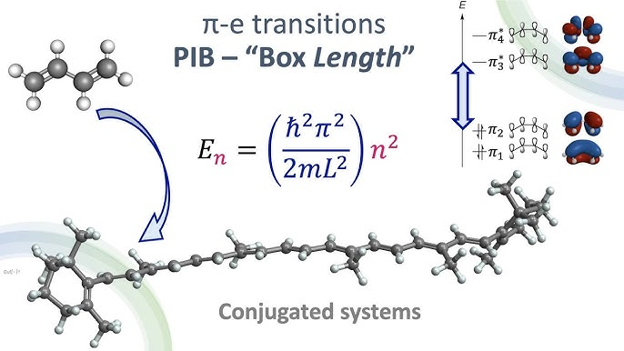

## The Model System: Butadiene

**Butadiene** $\text{C}_4\text{H}_6$: four carbons, **4 $\pi$-electrons**.

C–C single bond: **1.54 Å**

C=C double bond: **1.34 Å**

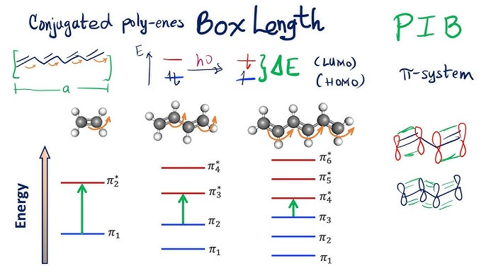

## Step 1: Box Length

Sum the bond lengths across the conjugated chain.

Each C contributes **one $\pi$-electron** $\rightarrow$ **4 electrons** total.

## Step 2: Energy Levels

1D particle-in-a-box energies:

$$E_n = \frac{n^2 h^2}{8mL^2}$$

$n = 1, 2, 3, \dots$, $\;m$ = electron mass, $\;L$ = box length.

## Step 3: Fill and Excite

4 electrons, 2 per level $\rightarrow$ fill $n=1$ and $n=2$.

**HOMO** $= n=2$, **LUMO** $= n=3$.

Absorption promotes one electron: $n=2 \rightarrow n=3$.

## Step 4: Photon Wavelength

Transition energy:
$$\Delta E = E_{n+1} - E_n$$

Set equal to photon energy:
$$\Delta E = \frac{hc}{\lambda}$$

Solve for $\lambda$ $\rightarrow$ the **color absorbed**.

## The Trend: Longer Chain, Redder Light

$\Delta E \propto \dfrac{1}{L^2}$

Bigger conjugation $\rightarrow$ **smaller $\Delta E$** $\rightarrow$ **longer $\lambda$**.

Explains why extended dyes are **deeply colored**.

## Beyond 1D: 2D Box

Aromatic rings and **graphene fragments**: confine in two directions.

$$E_{n_x,n_y} = \frac{h^2}{8m} \left( \frac{n_x^2}{L_x^2} + \frac{n_y^2}{L_y^2} \right)$$

Same physics, **two quantum numbers**.

# Takeaway

> The particle in a box turns a length and an electron count into a predicted absorption wavelength: longer conjugation gives a smaller gap and redder color.